# Organizing Academic Papers Using Ward Clustering

For my second year qualifying exams, I'm given academic papers to read by my three committee members. Each committe member has a different expertise (Computational Methods in Social Neuroscience, Memory, and Social Interaction and Faces) that allows me to learn about a wide bredth of my interests.

With approximately 20 papers per professor, I was overwhelmed on how to organize the content I was given. While some members were kind enough to organize the papers for me, others left it to me to make meaning out of what I was given. Interestingly, there was some overlap between topics and even overlap between suggested papers, which made me think to organize all of them together!

So, I turned to python to do it for me. I was aided by Brandon Rose's online tutorial: Document Clustering with Python, (http://brandonrose.org/clustering_mobile), which has a great in-depth explanation of all he did.

To begin, I used a command-line tool from xpdf called pdfottext to convert my pdfs to text files. The command is just `pdftotext file` but I sped it up with a for loop and fixed the encoding `for file in *.pdf; do pdftotext -enc UTF-8 "$file" ; done`.

I also did a quick renaming of the files to remember who they were reccommended by using rename: `rename 's/^/Luke - /' *`

```python
import numpy as np
import pandas as pd
import nltk
import re
import os
import codecs
from sklearn import feature_extraction
import mpld3
import matplotlib.pyplot as plt
import seaborn as sns

%matplotlib inline
```

## First I uploaded my files and set up my corpus of text

```python
import glob, os

# Get all the text files in my pdf directory
path = './pdf'
text_files = [f for f in os.listdir(path) if f.endswith('.txt')]

text_files.sort()

# Load them into an array
paper_text = []
for file in text_files:
    f = open(os.path.join(path, file), "r")
    paper_text.append(f.read())


# Get just the paper names (remove .txt)
paper_names = [x[:-4] for x in text_files]

# Get which committe member reccommended the file (get the first word)
committee = [x.split()[0] for x in text_files]
committee_order = ['Luke', 'Thalia', 'Jeremy']
```

## Then I used Brandon's code for ntlk tokenization

### (taken and modified from http://brandonrose.org/clustering_mobile)

```python
# load nltk's English stopwords as variable called 'stopwords'
stopwords = nltk.corpus.stopwords.words('english')

# load nltk's SnowballStemmer as variabled 'stemmer'
from nltk.stem.snowball import SnowballStemmer
stemmer = SnowballStemmer("english")

# here I define a tokenizer and stemmer which returns the set of stems in the text that it is passed

def tokenize_and_stem(text):
    # first tokenize by sentence, then by word to ensure that punctuation is caught as it's own token
    tokens = [word for sent in nltk.sent_tokenize(text) for word in nltk.word_tokenize(sent)]
    filtered_tokens = []
    # filter out any tokens not containing letters (e.g., numeric tokens, raw punctuation)
    for token in tokens:
        if re.search('[a-zA-Z]', token):
            filtered_tokens.append(token)
    stems = [stemmer.stem(t) for t in filtered_tokens]
    return stems


def tokenize_only(text):
    # first tokenize by sentence, then by word to ensure that punctuation is caught as it's own token
    tokens = [word.lower() for sent in nltk.sent_tokenize(text) for word in nltk.word_tokenize(sent)]
    filtered_tokens = []
    # filter out any tokens not containing letters (e.g., numeric tokens, raw punctuation)
    for token in tokens:
        if re.search('[a-zA-Z]', token):
            filtered_tokens.append(token)
    return filtered_tokens

#not super pythonic, no, not at all.
#use extend so it's a big flat list of vocab

totalvocab_stemmed = []
totalvocab_tokenized = []
for i in paper_text:
    allwords_stemmed = tokenize_and_stem(i) #for each item in 'paper_text', tokenize/stem
    totalvocab_stemmed.extend(allwords_stemmed) #extend the 'totalvocab_stemmed' list

    allwords_tokenized = tokenize_only(i)
    totalvocab_tokenized.extend(allwords_tokenized)


from sklearn.feature_extraction.text import TfidfVectorizer

#define vectorizer parameters
tfidf_vectorizer = TfidfVectorizer(max_df=0.8, max_features=200000,
                                 min_df=0.2, stop_words='english',
                                 use_idf=True, tokenizer=tokenize_and_stem, ngram_range=(1,4))

tfidf_matrix = tfidf_vectorizer.fit_transform(paper_text) #fit the vectorizer to paper_text
```

## Using Brandon's filtering method, I also checked that it seemed that topics were clustering into meaningful categories

```python
# (taken and modified from http://brandonrose.org/clustering_mobile)
from sklearn.cluster import KMeans

num_clusters = 10

km = KMeans(n_clusters=num_clusters)
km.fit(tfidf_matrix)

clusters = km.labels_.tolist()
terms = tfidf_vectorizer.get_feature_names()
vocab_frame = pd.DataFrame({'words': totalvocab_tokenized}, index = totalvocab_stemmed)

#sort cluster centers by proximity to centroid
order_centroids = km.cluster_centers_.argsort()[:, ::-1]

for i in range(num_clusters):
    print("Cluster %d words:" % i, end='')

    for ind in order_centroids[i, :10]: #replace 6 with n words per cluster
        print(' %s' % vocab_frame.loc[terms[ind].split(' '), :].values.tolist()[0][0], end = ',')
    print() #add whitespace
    print() #add whitespace
```

```
Cluster 0 words: story, narrative, voxel, fig, event, scrambled, al., et, distance, semantically,

Cluster 1 words: al., et, dynamic, decoding, nodes, ﬂuctuations, intact, fmri, preprint, connectivity,

Cluster 2 words: recall, movie, scenes, participant, items, listening, fig, narrative, audio, spoken,

Cluster 3 words: layers, training, sentence, language, neural, et, al., vector, embedding, transfer,

Cluster 4 words: reward, evolution, targets, actions, neuronal, construct, environment, transitions, q, prospect,

Cluster 5 words: face, familiar, et, al., person, identities, adapt, gobbini, biased, di,

Cluster 6 words: semantically, category, voxel, al., et, area, decoding, fmri, estimate, semantically,

Cluster 7 words: nodes, community, connectivity, k, scales, n, et, al., area, layers,

Cluster 8 words: social, interacting, conversation, actions, intentions, communication, mental, mirror, mind, musical,

Cluster 9 words: recall, event, topic, video, manuscript, boundary, episodes, trajectories, semantically, participant,
```

These track well with *my* understanding of how these texts should be categorized. Some are about face processing, some are about social interaction and some deal with communication and memory.

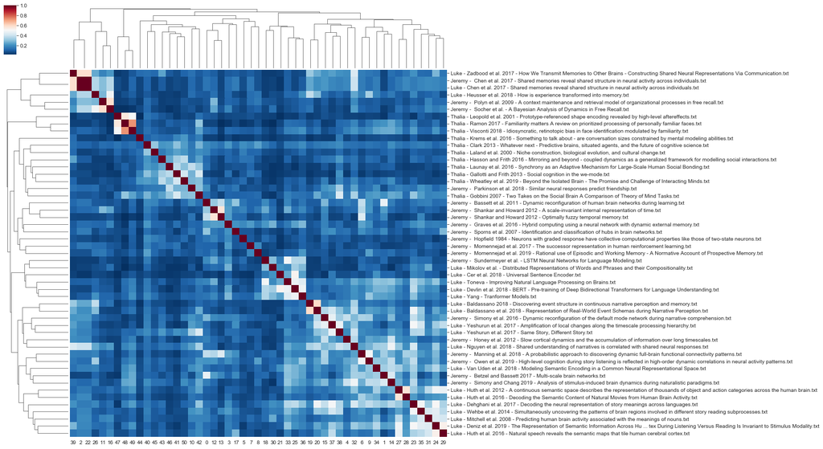

```python
from sklearn.metrics.pairwise import cosine_similarity
dist = 1 - cosine_similarity(tfidf_matrix)

sim = pd.DataFrame(cosine_similarity(tfidf_matrix))
sim.columns = text_files

sns.clustermap(sim.T, cmap='RdBu_r', figsize = (15,15))
```

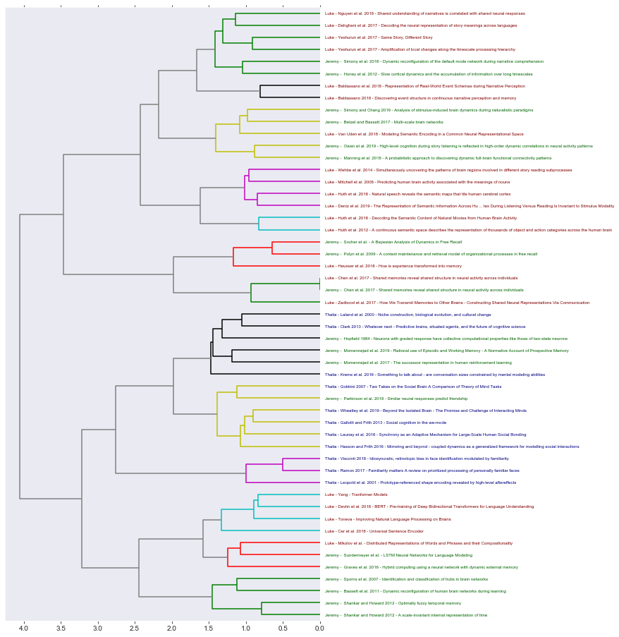

```python
from scipy.cluster.hierarchy import ward, dendrogram
import seaborn as sns
sns.set_style("dark")

linkage_matrix = ward(dist) #define the linkage_matrix using ward clustering pre-computed distances

fig, ax = plt.subplots(figsize=(8, 16)) # set size
ax = dendrogram(linkage_matrix, orientation="left", labels=paper_names,color_threshold=1.5, above_threshold_color='gray');


plt.tick_params(\
    axis= 'x',          # changes apply to the x-axis
    which='both',      # both major and minor ticks are affected
    bottom='off',
    top='off',
    labelbottom='off')


# Recolor X Labels
ax = plt.gca()
xlbls = ax.get_ymajorticklabels()


my_palette = ['maroon', 'navy', 'darkgreen']
num=0
for lbl in xlbls:
    val=committee_order.index(str(lbl).split(" ")[2].replace("'",""))
    lbl.set_color(my_palette[val])
    num+=1

# save figure
plt.savefig('specialist_grouping.png', dpi=200, bbox_inches='tight') #save figure as ward_clusters
```